# Introduction Exploring Data with R

NZSA/ORSNZ 2016

## Outline

- Session 1: How to think about data, and getting started plotting with the grammar of graphics
- Session 2: Wrangling data into shape, useful practices, cognitive perception
- Session 3: Advanced graphics, layering, using maps

## Building charts piecewise

[figure not shown]

## Education

Read the OECD PISA data

```r
student <- readRDS("../data/student_sub.rds")
dim(student)
```

```
#> [1] 271323     50
```

```r
student$ST04Q01 <- factor(student$ST04Q01,
  levels=c(1,2), labels=c("Female", "Male"))
```

Calculate the statistics: Mean difference

```r
student.stats <- student %>%
  group_by(CNT) %>%
  summarise(wmathgap=weighted.mean(PV1MATH[ST04Q01=="Male"],
                  w=SENWGT_STU[ST04Q01=="Male"], na.rm=T)-
               weighted.mean(PV1MATH[ST04Q01=="Female"],
                  w=SENWGT_STU[ST04Q01=="Female"], na.rm=T))
kable(head(student.stats))
```

| CNT | wmathgap |
| --- | --- |
| ARE | -5.1 |
| AUS | 12.3 |
| AUT | 21.9 |
| BEL | 11.4 |
| BGR | -2.1 |
| BRA | 21.1 |

## Map

- Means are point estimates
- Map mean difference to point geom, using position along a line

## Plot - Need to Order!

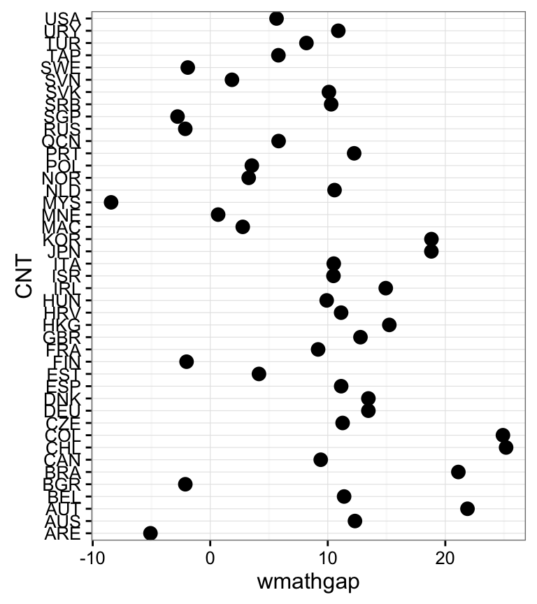

```r
ggplot(data=student.stats) +
  geom_point(aes(x=CNT, y=wmathgap), size=3) +
 coord_flip() + theme_bw()
```

## Arrange

- Arrange: by country
- Order by magnitude of difference

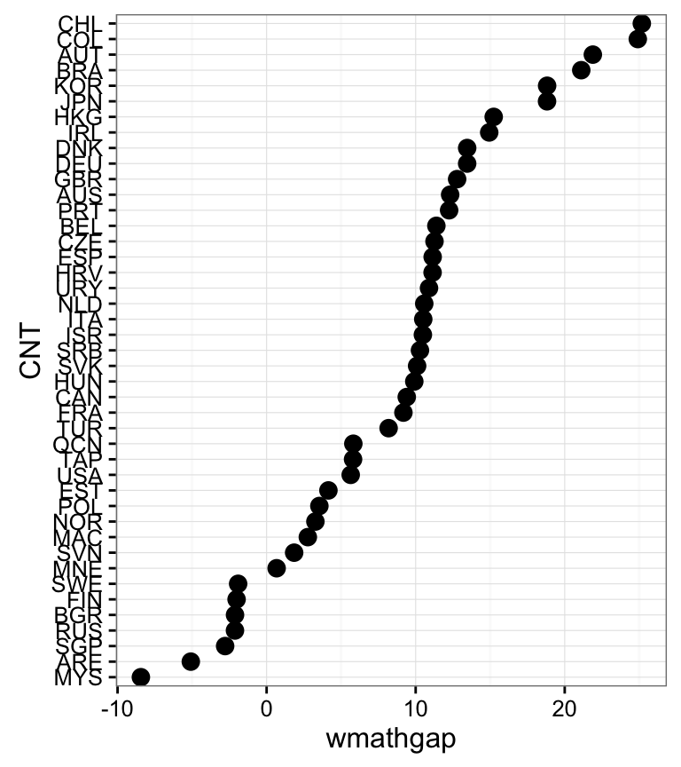

```r
student.stats$CNT <- factor(student.stats$CNT,
    levels=student.stats$CNT[order(student.stats$wmathgap)])
ggplot(data=student.stats) +
  geom_point(aes(x=CNT, y=wmathgap), size=3) +
 coord_flip() + theme_bw()
```

## Inference

Create bootstrap confidence intervals for each mean difference

```r
cifn <- function(d, i) {
  x <- d[i,]
  ci <- weighted.mean(x$PV1MATH[x$ST04Q01=="Male"],
          w=x$SENWGT_STU[x$ST04Q01=="Male"], na.rm=T)-
        weighted.mean(x$PV1MATH[x$ST04Q01=="Female"],
          w=x$SENWGT_STU[x$ST04Q01=="Female"], na.rm=T)
  ci
}
```

```r
bootfn <- function(d) {
  r <- boot(d, statistic=cifn, R=100)
  l <- sort(r$t)[5]
  u <- sort(r$t)[95]
  ci <- c(l, u)
  return(ci)
}
```

Apply ci functions to data

```r
student.summary.gap.boot <- student %>%
  split(.$CNT) %>% purrr::map(bootfn) %>% data.frame() %>%
  gather(CNT, value)
student.summary.gap.boot$ci <-
  rep(c("ml","mu"),
      length(unique(student.summary.gap.boot$CNT)))
student.summary.gap.boot.wide <-
  student.summary.gap.boot %>%
  spread(ci, value)
student.summary.gap <- merge(student.stats,
  student.summary.gap.boot.wide)
kable(head(student.summary.gap))
```

| CNT | wmathgap | ml | mu |
| --- | --- | --- | --- |
| ARE | -5.1 | -8.3 | -1.7 |
| AUS | 12.3 | 9.8 | 14.9 |
| AUT | 21.9 | 16.0 | 26.1 |
| BEL | 11.4 | 7.2 | 15.9 |
| BGR | -2.1 | -7.1 | 0.8 |
| BRA | 21.1 | 16.3 | 25.4 |

## Plot

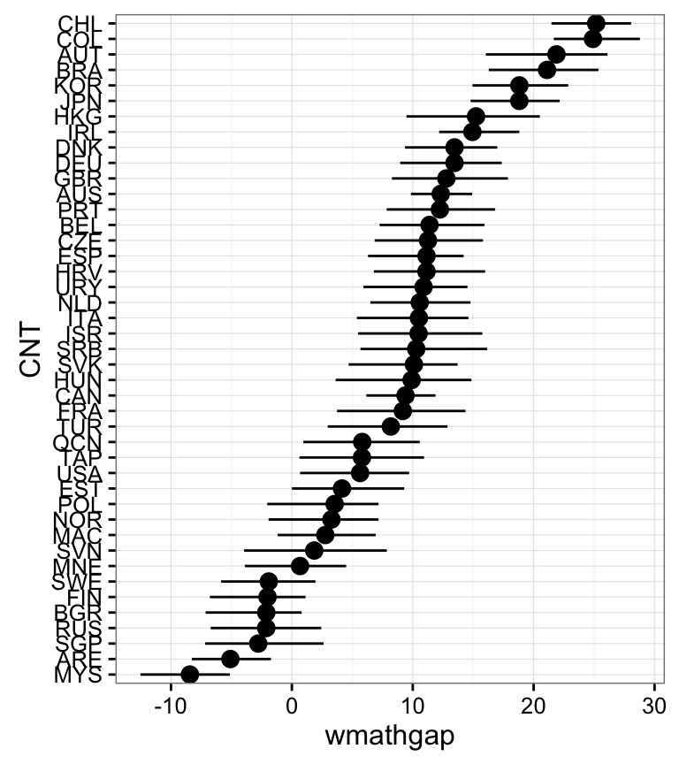

```r
ggplot(data=student.summary.gap) +
  geom_point(aes(x=CNT, y=wmathgap), size=3) +
  geom_segment(aes(x=CNT, xend=CNT, y=ml, yend=mu)) +
  coord_flip() + theme_bw()
```

## Enhance

Match three digit codes to country names, more recognizable labels

```r
student.summary.gap$name <- NA
for (i in 1:length(student.summary.gap$name))
  student.summary.gap$name[i] <-
  isoToName(as.character(student.summary.gap$CNT[i]))
# QCN is Shanghai, not whole of China -
# Don't know what country TAP is
student.summary.gap$name[
  student.summary.gap$CNT == "QCN"] <-
  isoToName("CHN")
student.summary.gap$name[
  student.summary.gap$CNT == "TAP"] <-
  "TAP"
```

Create categorical gap variable to draw attention to significant difference

```r
student.summary.gap$wmathgap_cat <- "same"
student.summary.gap$wmathgap_cat[
  student.summary.gap$ml > 0] <- "boys"
student.summary.gap$wmathgap_cat[
  student.summary.gap$mu < 0] <- "girls"
kable(head(student.summary.gap))
```

| CNT | wmathgap | ml | mu | name | wmathgap_cat |
| --- | --- | --- | --- | --- | --- |
| ARE | -5.1 | -8.3 | -1.7 | United Arab Emirates | girls |
| AUS | 12.3 | 9.8 | 14.9 | Australia | boys |
| AUT | 21.9 | 16.0 | 26.1 | Austria | boys |
| BEL | 11.4 | 7.2 | 15.9 | Belgium | boys |
| BGR | -2.1 | -7.1 | 0.8 | Bulgaria | same |
| BRA | 21.1 | 16.3 | 25.4 | Brazil | boys |

## Order Again

```r
student.summary.gap$name <- factor(student.summary.gap$name,
    levels=student.summary.gap$name[
      order(student.summary.gap$wmathgap)])
kable(head(student.summary.gap))
```

| CNT | wmathgap | ml | mu | name | wmathgap_cat |
| --- | --- | --- | --- | --- | --- |
| ARE | -5.1 | -8.3 | -1.7 | United Arab Emirates | girls |
| AUS | 12.3 | 9.8 | 14.9 | Australia | boys |
| AUT | 21.9 | 16.0 | 26.1 | Austria | boys |
| BEL | 11.4 | 7.2 | 15.9 | Belgium | boys |
| BGR | -2.1 | -7.1 | 0.8 | Bulgaria | same |
| BRA | 21.1 | 16.3 | 25.4 | Brazil | boys |

## Plot - with Guide Lines

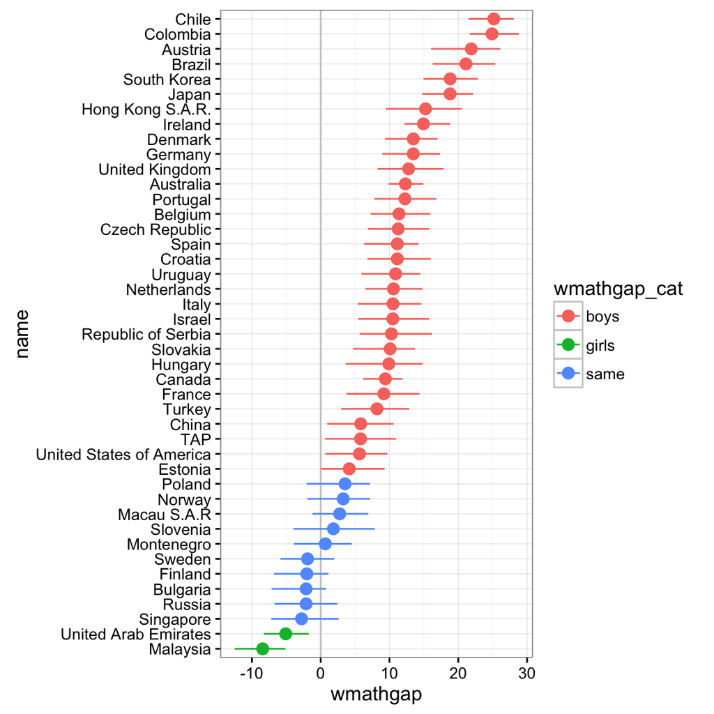

```r
ggplot(data=student.summary.gap) +
  geom_hline(yintercept=0, colour="grey80") +
  geom_point(aes(x=name, y=wmathgap, color=wmathgap_cat),
             size=3) +
  geom_segment(aes(x=name, xend=name, y=ml, yend=mu,
                   color=wmathgap_cat)) +
  coord_flip() + theme_bw()
```

## Enhance More

- Labels
- Axis limits
- Grid lines
- Color

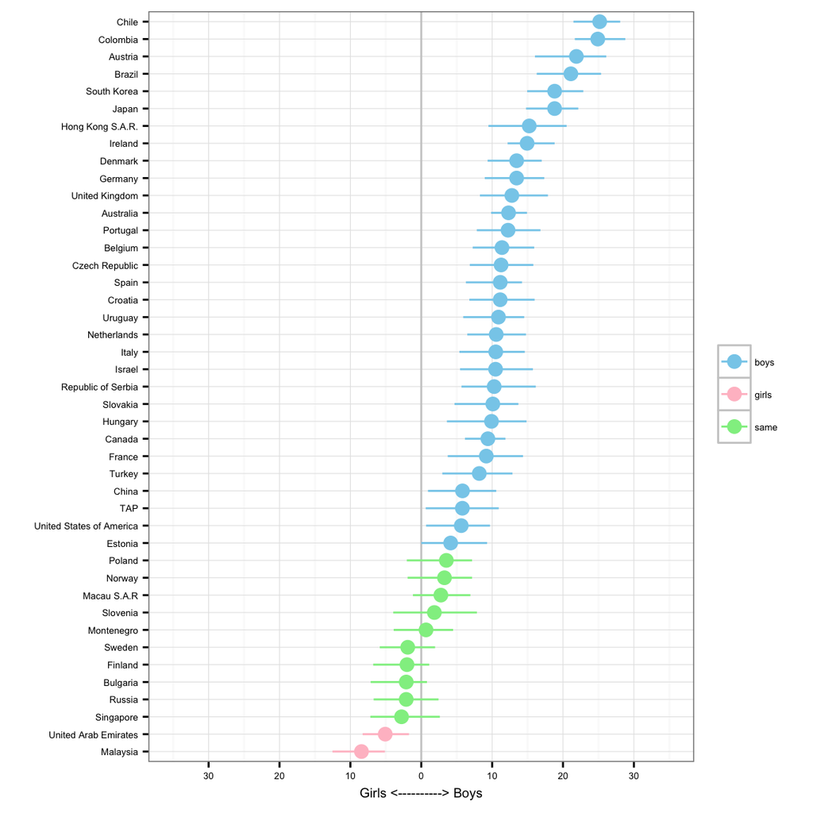

```r
ggplot(data=student.summary.gap) +
  geom_hline(yintercept=0, colour="grey80") +
  geom_point(aes(x=name, y=wmathgap, color=wmathgap_cat), size=3) +
  geom_segment(aes(x=name, xend=name, y=ml, yend=mu,
     color=wmathgap_cat)) + xlab("") +
  scale_colour_manual("", values=c("boys"="skyblue",
    "girls"="pink", "same"="lightgreen")) +
  scale_y_continuous("Girls <----------> Boys",
    breaks=seq(-30, 30, 10), limits=c(-35, 35),
    labels=c(seq(30, 0, -10), seq(10, 30, 10))) +
  coord_flip() + theme_bw() +
  theme(axis.text.x = element_text(size=5),
        axis.text.y = element_text(size=5),
        axis.title = element_text(size=7),
        legend.text = element_text(size=5),
        legend.title = element_text(size=5))
```

## Interactive

```r
ggplotly()
```

## Maps

Map data is essentially a set of points, and line segments. You can get maps from various sources, and wrangle the files/data into an R object. This can be merged with data to provide spatial context to problems.

```r
world <- getMap(resolution = "low")
extractPolys <- function(p) {
  polys <- NULL
  for (i in 1:length(p)) {
    for (j in 1:length(p[[i]]@Polygons)) {
      x <- p[[i]]@Polygons[[j]]@coords
      polys$lon <- c(polys$lon, x[,1])
      polys$lat <- c(polys$lat, x[,2])
      polys$ID <- c(polys$ID, rep(p[[i]]@ID, nrow(x)))
      polys$region <- c(polys$region,
        rep(paste(p[[i]]@ID, j, sep="_"), nrow(x)))
      polys$order <- c(polys$order, 1:nrow(x))
    }
  }
  return(data.frame(polys))
}
polys <- extractPolys(world@polygons)
```

Here is what is looks like:

```r
kable(head(polys))
```

| lon | lat | ID | region | order |
| --- | --- | --- | --- | --- |
| -70 | 12 | Aruba | Aruba_1 | 1 |
| -70 | 12 | Aruba | Aruba_1 | 2 |
| -70 | 12 | Aruba | Aruba_1 | 3 |
| -70 | 12 | Aruba | Aruba_1 | 4 |
| -70 | 13 | Aruba | Aruba_1 | 5 |
| -70 | 13 | Aruba | Aruba_1 | 6 |

## A map is a set of points…

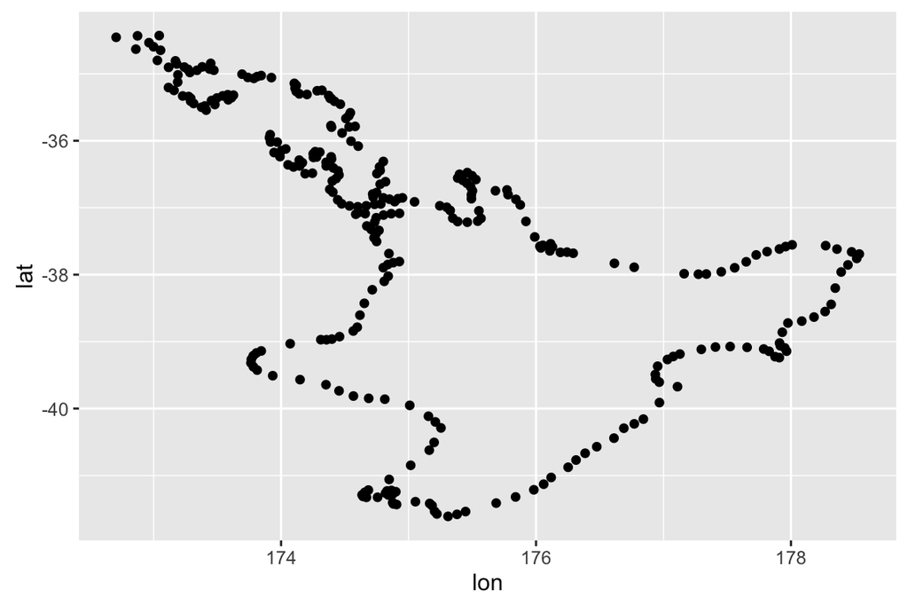

```r
ggplot(data=filter(polys, region=="New Zealand_2"),
       aes(x=lon, y=lat)) +
  geom_point()
```

## connected in the right order

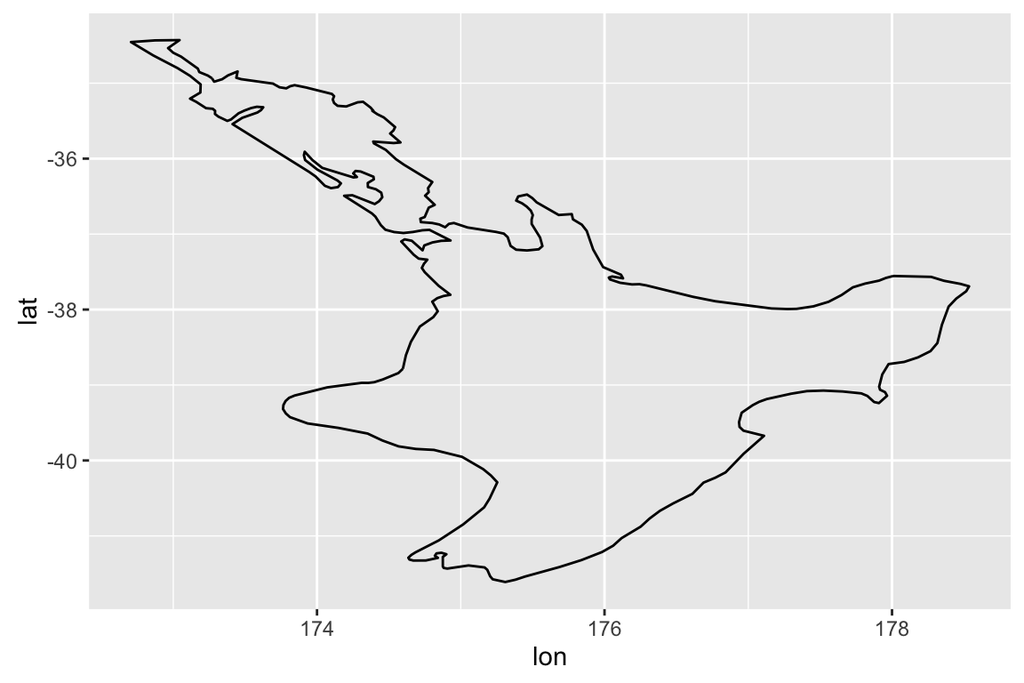

```r
ggplot(data=filter(polys, region=="New Zealand_2"),
       aes(x=lon, y=lat, order=order)) +
  geom_path()
```

## as a group

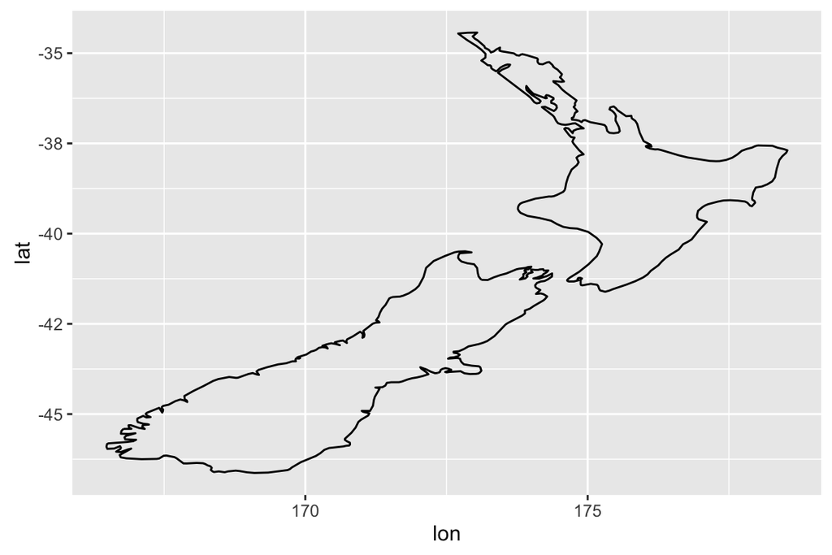

```r
ggplot(data=filter(polys,
                   region=="New Zealand_1" | region=="New Zealand_2"),
       aes(x=lon, y=lat, group=region, order=order)) +
  geom_path()
```

Join education data with map polygons

```r
polys <- polys %>% rename(name = ID)
student.map <- left_join(
  student.summary.gap, polys)
student.map <- student.map %>%
  arrange(region, order)
```

## Map theme

Make it look like a map, by tweaking the plot appearance

```r
theme_map <- theme_bw()
theme_map$line <- element_blank()
theme_map$strip.text <- element_blank()
theme_map$axis.text <- element_blank()
theme_map$plot.title <- element_blank()
theme_map$axis.title <- element_blank()
theme_map$panel.border <- element_rect(
  colour = "grey90", size=1, fill=NA)
```

## Plot - axes, colors, coord system

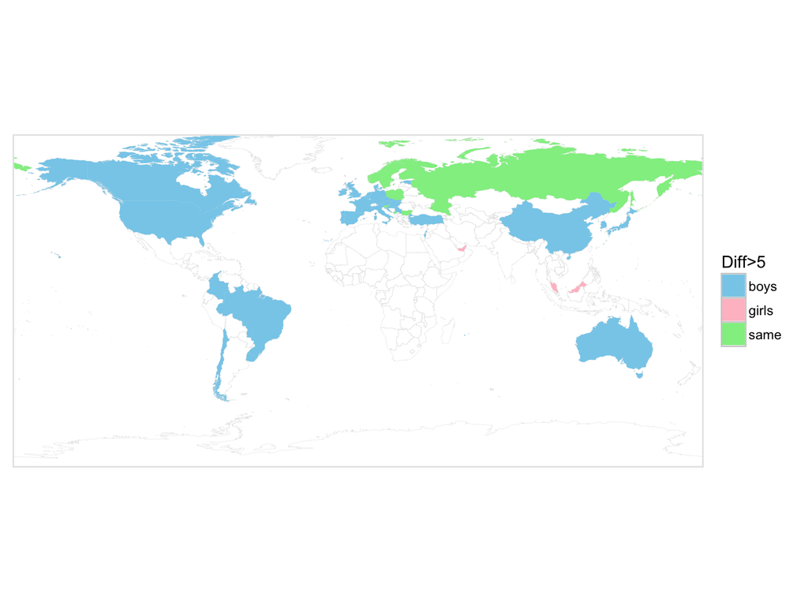

```r
ggplot(data=polys) +
  geom_path(aes(x=lon, y=lat, group=region, order=order),
            colour=I("grey90"), size=0.1) +
  geom_polygon(data=student.map, aes(x=lon, y=lat,
            group=region, order=order,
            fill=wmathgap_cat)) +
  scale_fill_manual("Diff>5", values=c("boys"="skyblue",
                                    "girls"="pink",
                                    "same"="lightgreen")) +
  scale_x_continuous(expand=c(0,0)) +
  scale_y_continuous(expand=c(0,0)) +
  coord_equal() + theme_map
```

## Interactive

```r
ggplotly()
```

## Raster maps

Image maps can also be pulled using the package `ggmap` to use as the background for data.

[figure not shown]

```r
gm <- get_googlemap(center = c(lon=144.96, lat=-37.815), zoom=14)
ggmap(gm)
```

[figure not shown]

```r
sensor_loc <- read_csv("../data/Pedestrian_Sensor_Locations.csv")
ggmap(gm) + geom_point(data=sensor_loc, aes(x=Longitude, y=Latitude))
```

## Multiple Plots on a Sheet

Occasionally you would like to organize your plots in special ways. The `gridExtra` can be used to take individual plots and lay them out together.

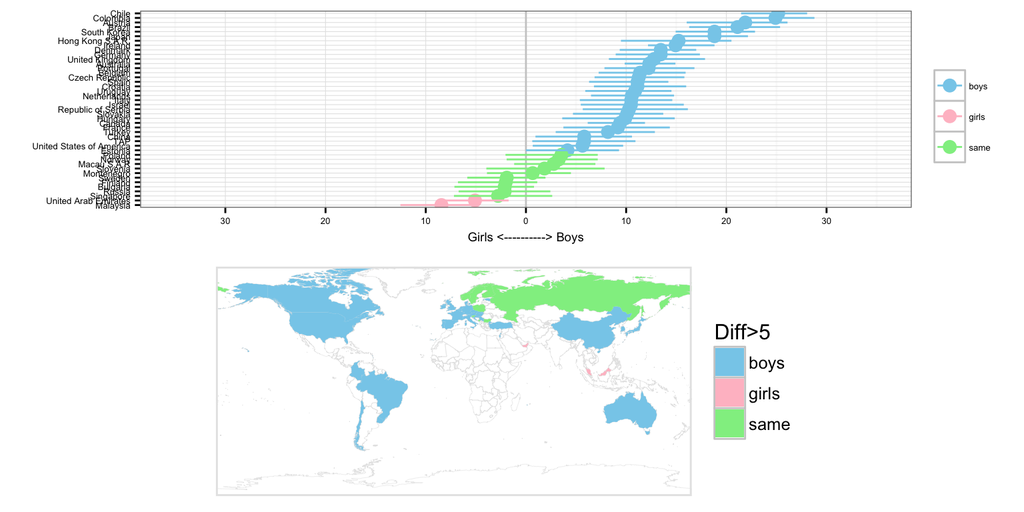

```r
grid.arrange(p1, p2)
```

## Data Competition

- Download the earthquake data from David Harte's monitoring site
- ftp://ftp.gns.cri.nz/pub/davidh/sslib/src/ssNZ_3.0-134.tar.gz
- Using the tools discussed in this workshop, make a couple of plots that tell a story
- Show them off to the group between 3:40-3:55pm
- Best person/team plots win a prize

## Credit

Notes prepared by Di Cook, building on joint workshops with Carson Sievert, Heike Hofmann, Eric Hare, Hadley Wickham.

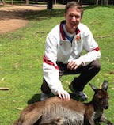

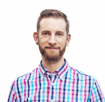

This work is licensed under a [Creative Commons Attribution-ShareAlike 4.0 International License](http://creativecommons.org/licenses/by-sa/4.0/).